# Trash Layer Prep (Jambeck et al 2015)

Proposed data for trash from [**Jambeck et al 2015: Plastic waste inputs from land into the ocean**](http://science.sciencemag.org/content/347/6223/768.full.pdf+html)

**the Jambeck et al method includes:**

- 1. the mass of waste generated per capita annually;
- 2. the percentage of waste that is plastic; and
- 3. the percentage of plastic waste that is mismanaged and, therefore, has the potential to enter the ocean as marine debris (12) (data S1). By applying a range of conversion rates from mismanaged waste to marine debris, we estimated the mass of plastic waste entering the ocean from each country in 2010, used population growth data (13) to project the increase in mass to 2025, and predicted growth in the percentage of waste that is plastic.

## Potential path forward:

**Status**: 2010 modeled values / ref point  
**Ref pt**: maximum for Europe in 2010 or 2025 (explored below)  
**Trend**: use projected 2025 data to get 5-year trend? Or just use trend for a different CW component as the trend of the whole goal.

## Filter Baltic data

Note: these data are for all of these countries, so do fraction of coastline or something to downweight

```r
## filter Baltic data, save intermediate
baltic = data_clean %>%
  filter(country %in% baltic_lookup$country_name)
#write.csv(baltic, '~/github/bhi/baltic2015/prep/CW/trash/intermediate/trash_jambeck_baltic.csv')
```

## Modeled Mismanaged plastic waste 2010

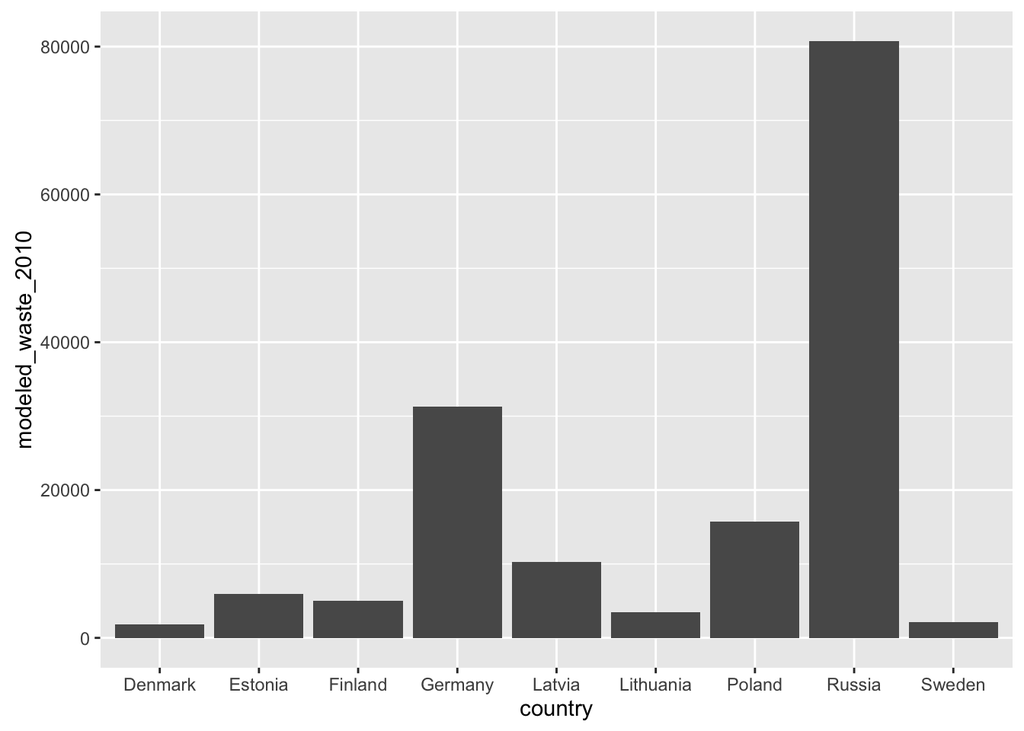

## Modeled Mismanaged plastic waste 2025

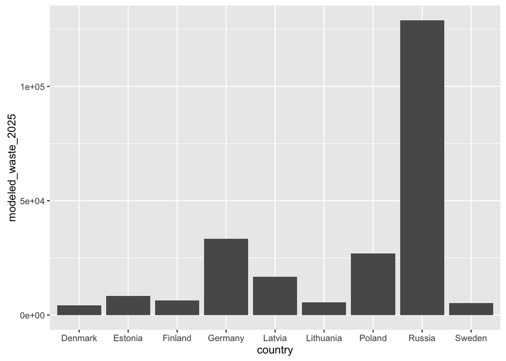

## Prepare data layer for Toolbox

**Plan:**

Modeled Mismanaged plastic waste data (tonnes) are reported for each country. We will create scores for each country related to the reference point, and then apply to all of that country’s BHI regions under the assumption that the management for the country is probably equal. Note: for BHI 2.0, would be better to recalcuate their model using coastal population for each BHI region.

**Reference points**

Need a min and a max reference point (they will ultimately be inverted for CW but not as a pressure)

- **Minimum modeled trash entering the ocean = 0** (we want no trash entering the ocean)
- **Maximum modeled trash entering the ocean = highest Eurpean country in 2025** (we have 2025 modeled data. Is this reasonable, ie do we think that the maximum trash we see in Europe, or is that too high because it’s based on a larger population that we don’t have now? Another option would be to make a linear model between 2010 and 2025 and choose a year more like 2015?)

Note: Because Russia is reported as a whole country, we used the proportion of population in Kaliningrad+St Petersburg to the coastal popultion reported by Jambeck et al. See figure below.

## To find reference point, combine Europe with Russia, downweight Russia

It made sense to downweight Kaliningrad and St Petersburg by coastal population density instead of total Russia population density because of the distribution along the coasts:

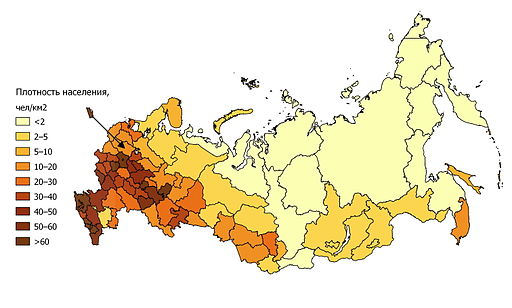

Then find ref point as the max of Europe, but compare 2010 v. 2025 to determine whether it’s worth trying to interpolate/model to find a reference point in ~2015. Conclusion, probably not worth it, so we could just pick either 2010 or 2025 since those data are already modeled/reported by Jambeck et al.

```
## [1] 0.4651547
```

```
## [1] "max trash for 2010 is 67549 (United Kingdom)"
```

```
## [1] "max trash for 2025 is 94165 (United Kingdom)"
```

### Plot exploring ref point as max of Europe (including Russia) in 2010 v. 2025

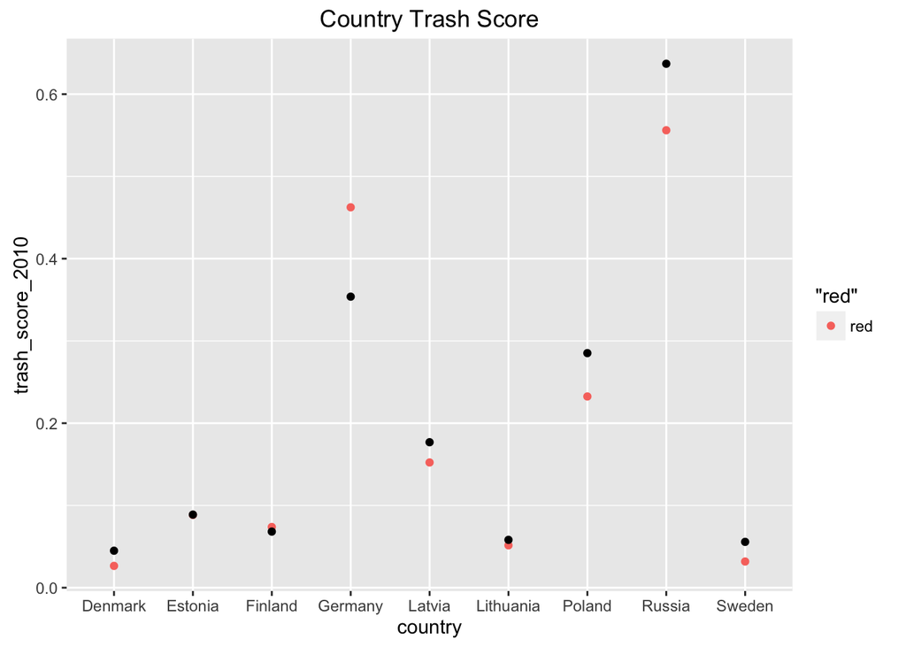